# Lab 2A

Feature space expansions

2026

# 1 Getting Started: Loading the Dataset

Before you begin the practical, you need to load the required dataset into R. To ensure a smooth workflow, please follow one of the two options below:

**Option 1: Using a Dedicated Folder**

Create a specific folder for this assignment and place the dataset file inside it. You can then load the data using the `load()` function by specifying the correct file path. (Note for Windows users: Please ensure you change all backslashes `\` in your copied file path to forward slashes `/` in R).

For **Mac** users, your path will look like this:

```r
load("/Users/your_username/Documents/folder_name/dataset_name.RData")
```

For **Windows** users, your path will look like this:

```r
load("C:/Users/your_username/Documents/folder_name/dataset_name.RData")
```

**Option 2: Using an R Project**

Create an R Project (`.Rproj`) for this assignment and store the dataset directly within that project folder. Make sure to open RStudio by double-clicking the `.Rproj` file. This automatically sets your working directory, allowing you to load the dataset directly without a long path:

```r
load("dataset_name.RData")
```

**Note for this specific lab:** For this lab, you need to download and load two datasets: `bmi.Rdata` and `climate.Rdata`.

# 2 Introduction

In this lab, we will apply the methods discussed in the lecture. We explore **feature space expansions** to model non-linear relationships in regression. Instead of restricting ourselves to simple linear models, we expand the predictor space using:

- Polynomial functions (e.g., $x, x^2, x^3$)
- Spline basis functions (B-splines and natural splines)

This allows linear regression to capture flexible, non-linear patterns while remaining linear in the coefficients.

## 2.1 Data sets (BMI data and Climate change data)

We will work with two data sets:

- **BMI data (`bmi`)**: BMI measurements of Dutch boys aged 0–21
- **Climate data (`climate`)**: yearly temperature change (1961–2022) across continents

Throughout the lab, focus on how increasing flexibility affects the fitted curves, the interpretation of results, and extrapolation beyond the observed data.

## 2.2 Required packages

For this lab, you need to load the following packages:

- `ggplot2` – for data visualization and plotting
- `dplyr` – for data manipulation and transformation
- `splines` – for creating spline basis functions (`bs()`, `ns()`)
- `patchwork` – for combining multiple ggplots into a single figure
- `caret` – for model training, cross-validation, and performance evaluation

**Hint:** Use the `library()` function to load the required packages.

**Show Answer**

```r
## Note:
# If the tidyverse package is installed, you do NOT need to
# load ggplot2 and dplyr separately.

library(ggplot2)
library(dplyr)
library(splines)
library(patchwork)

load("data/bmi.Rdata")
load("data/climate.Rdata")
```

Notes: Make sure the `.Rdata` files are located in your working directory. If needed, check your working directory with:`getwd()`

# 3 BMI dataset

The data set for this exercise is `bmi`. The data are BMI measurements of 7294 Dutch boys between 0 and 21 years of age. Our goal is to explore the relationship between age and BMI, and to assess whether a simple smooth curve adequately captures the pattern in the data.

## 3.1 Visualize the data

1. Display a scatter plot with a smooth regression line with `age` on the x-axis and `bmi` on y-axis.

   **Hint:** Use `ggplot()` with `geom_point()` and `geom_smooth()` layers.

**Show Answer**

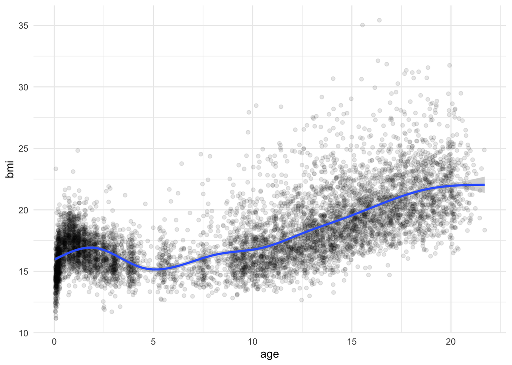

```r
ggplot(bmi, aes(x = age, y = bmi)) +
  geom_point(alpha = 0.1) +
  geom_smooth() +
  theme_minimal()
```

The default smooth regression line produced by `ggplot` does not adequately capture the pattern in the data, particularly for ages between 0 and 5. The relationship appears more complex in this early age range. We will therefore explore whether a more flexible model can provide a better fit. let’s go further.

## 3.2 Polynomial regression

1. Reproduce the plot from part (a), but now fit a polynomial regression model using a linear model:
- Use `geom_smooth(method = "lm", formula = y ~ poly(x, ...))`
- Use a polynomial in age with `poly(x, degree)`
- Try several degrees (e.g., 2, 3, 4, …)

  Choose the smallest degree that provides a satisfactory fit (to avoid overfitting / high variance).

  **Hint:** Replace the dots with a number, e.g. `poly(x, 4)`, and layer multiple `geom_smooth()` calls with different degrees.

**Show Answer**

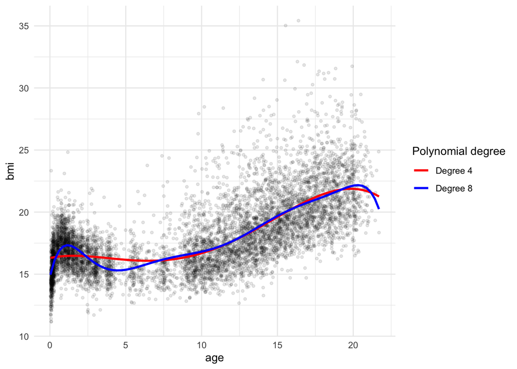

```r
ggplot(bmi, aes(x = age, y = bmi)) +
  geom_point(alpha = 0.1, size = 1) +
  geom_smooth(method = "lm", se = FALSE,
              formula = y ~ poly(x, 4),
              aes(color = "Degree 4")) +
  geom_smooth(method = "lm", se = FALSE,
              formula = y ~ poly(x, 8),
              aes(color = "Degree 8")) +
  scale_color_manual(values = c("Degree 4" = "red",
                                "Degree 8" = "blue")) +
  labs(color = "Polynomial degree") +
  theme_minimal()
```

- Investigate what happens when the polynomial degree is increased. Fit polynomial regression models with, for example, degree 10 and 12, and compare the fitted curves. What changes do you observe? Do higher degrees improve the fit? Do you see any signs of overfitting? Note that high-degree polynomials, increase flexibility, reduce bias, increase variance and usually behave poorly at boundaries.

  **Hint:** Try adding `formula = y ~ poly(x, 10)` and `12` to see how the tails (ends of the curves) behave.

**Show Answer**

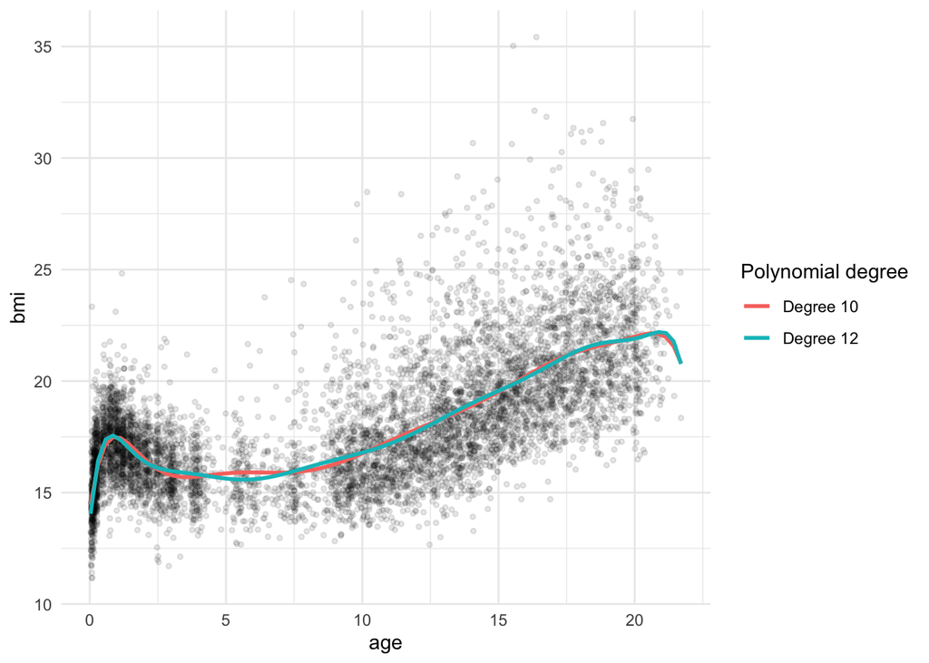

```r
ggplot(bmi, aes(x = age, y = bmi)) +
  geom_point(alpha = 0.1, size = 1) +
  geom_smooth(method = "lm", se = FALSE,
              formula = y ~ poly(x, 10),
              aes(color = "Degree 10")) +
  geom_smooth(method = "lm", se = FALSE,
              formula = y ~ poly(x, 12),
              aes(color = "Degree 12")) +
  labs(color = "Polynomial degree") +
  theme_minimal()
```

## 3.3 B-spline regression

1. Reproduce the previous plot, but now fit a B-spline regression line using: `geom_smooth(method = "lm", formula = y ~ bs(x, df = ...))`. Start with a small value of df and increase it until the fit looks satisfactory (avoid an overly wiggly curve). Then add a natural spline regression line with the same df: `geom_smooth(method = "lm", formula = y ~ ns(x, df = ...))`. What is the main difference between the B-spline and the natural spline fit (especially near the boundaries)?

   **Hint:** Test around `df = 8` for both `bs()` and `ns()`, and pay close attention to the curve shapes near age 0 and age 21.

**Show Answer**

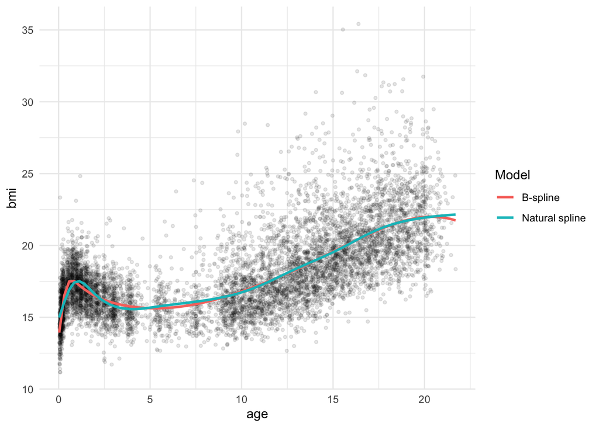

```r
ggplot(bmi, aes(x = age, y = bmi)) +
  geom_point(alpha = 0.1, size = 1) +
  geom_smooth(method = "lm", se = FALSE,
              formula = y ~ bs(x, df = 8),
              aes(color = "B-spline")) +
  geom_smooth(method = "lm", se = FALSE,
              formula = y ~ ns(x, df = 8),
              aes(color = "Natural spline")) +
  labs(color = "Model") +
  theme_minimal()
```

It seems that Both are flexible spline fits. Natural splines are constrained to be linear beyond the boundary knots, so they often behave more stably at the extremes (near very low/high ages).

2. In terms of the bias-variance trade-off, much can be gained by fitting a spline to these data by specifying the `knots` instead of the `df`. Fit a B-spline regression model by specifying a single `knot`. Choose a knot location that yields a satisfactory fit.

   **Hint:** Use `formula = y ~ bs(x, knots = ...)` and try placing the knot where the data trend changes direction, for instance around 0.5 or 0.7.

**Show Answer**

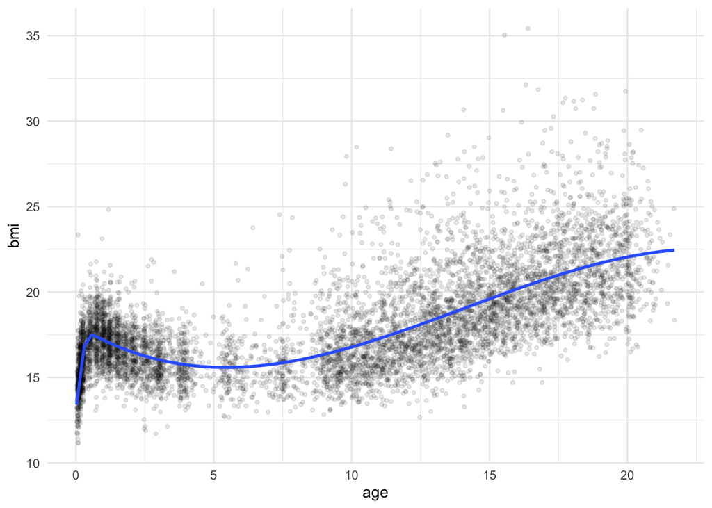

```r
ggplot(bmi, aes(x = age, y = bmi)) +
  geom_point(alpha = 0.1, size = 1) +
  geom_smooth(method = "lm",
              formula = y ~ bs(x, knots = 0.7),
              se = FALSE) +
  theme_minimal()
```

Experiment with different knot locations and compare the fitted curves. How does the choice of knot influence flexibility in different age ranges?

**Hint:** Overlay several `geom_smooth()` layers setting `knots` to different values (e.g., 0.5, 2, 6) to see local adjustments.

**Show Answer**

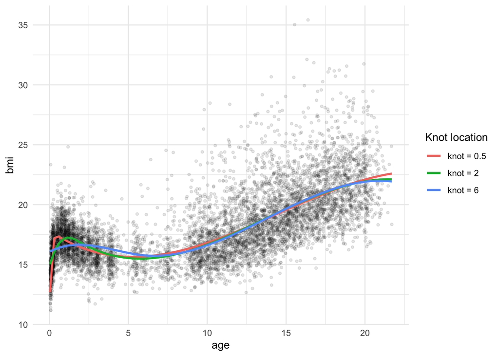

```r
ggplot(bmi, aes(x = age, y = bmi)) +
  geom_point(alpha = 0.1, size = 1) +
  geom_smooth(method = "lm", se = FALSE,
              formula = y ~ bs(x, knots = 0.5),
              aes(color = "knot = 0.5")) +
  geom_smooth(method = "lm", se = FALSE,
              formula = y ~ bs(x, knots = 2),
              aes(color = "knot = 2")) +
  geom_smooth(method = "lm", se = FALSE,
              formula = y ~ bs(x, knots = 6),
              aes(color = "knot = 6")) +
  labs(color = "Knot location") +
  theme_minimal()
```

# 4 Climate change dataset

The file `climate.Rdata` contains the dataset `climate`, with yearly temperature change `temp` from **1961 to 2022** for countries across five continents.

## 4.1 Visualize the data

1. Create a scatter plot of temperature change over time:
- `year` on the x-axis
- `temp` on the y-axis
- color points and smooth trend lines by `Continent`

  **Hint:** Map `color = Continent` inside your main `aes()` call so that both `geom_point()` and `geom_smooth()` inherit it.

**Show Answer**

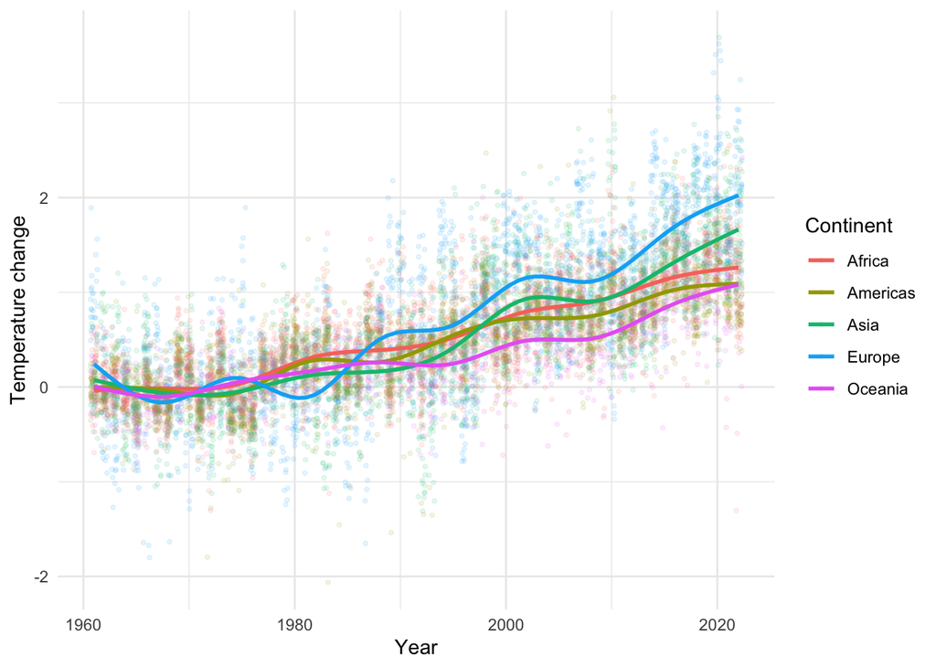

```r
ggplot(climate, aes(x = year, y = temp, color = Continent)) +
  geom_point(alpha = 0.1,
             position = position_jitter(width = 0.35),
             size = 0.8) +
  geom_smooth(se = FALSE) +
  labs(x = "Year", y = "Temperature change", color = "Continent") +
  theme_minimal()
```

The plot suggests an interaction between year and Continent, as the regression lines are not parallel and differ in slope across continents. This indicates that the trend in temperature change over time varies by continent. However, the large number of observations makes the overall pattern difficult to interpret clearly. To obtain a clearer view of the trends, we can do the following

- Reduce visual noise by plotting the yearly average temperature change within each continent, and
- Display separate panels for each continent using faceting.
2. Add the variable `ave_temp` with the yearly averages of `temp` per continent to `climate`.

   **Hint:** You can use `full_join()` combined with `summarize(..., .by = c(year, Continent))`.

**Show Answer**

```r
climate  <- full_join(climate, summarize(climate, ave_temp = mean(temp),
                      .by   = c(year, Continent)))

# climate <- climate %>%
#   group_by(year, Continent) %>%
#   mutate(ave_temp = mean(temp)) %>%
#   ungroup()

# cl_join <- full_join(
#   climate,
#   summarize(climate, ave_temp = mean(temp), .by = c(year, Continent))
# )
#
# cl_mut <- climate %>%
#   group_by(year, Continent) %>%
#   mutate(ave_temp = mean(temp)) %>%
#   ungroup()
#
# nrow(cl_join); nrow(cl_mut)      # should match
# names(cl_join); names(cl_mut)    # should match
#
# # Compare after sorting rows
# all.equal(
#   arrange(cl_join, year, Continent),
#   arrange(cl_mut, year, Continent),
#   check.attributes = FALSE
# )
```

3. Reproduce the previous plot with `ave_temp` in `geom_point()`, and with `facet_grid(cols = vars(Continent))`.

   **Hint:** Map `y = ave_temp` locally inside your `geom_point()`, and add the `facet_grid()` layer at the end.

**Show Answer**

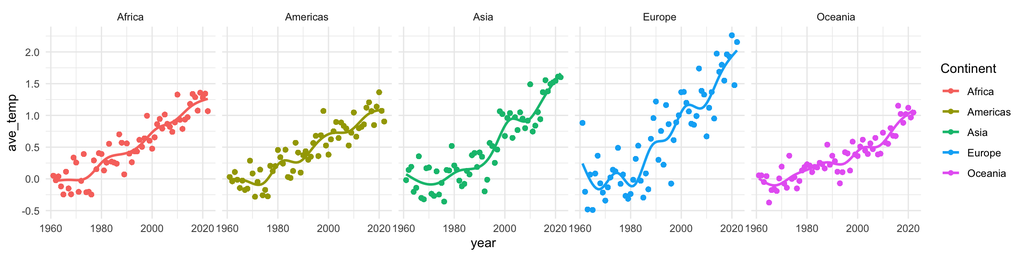

```r
ggplot(climate, aes(year, temp, col = Continent)) +
  geom_point(aes(year, ave_temp)) +
  geom_smooth(se = F) +
  facet_grid(cols = vars(Continent)) & theme_minimal()
```

```r
# ggplot(climate, aes(x = year, y = ave_temp, color = Continent)) +
#   geom_point() +
#   geom_smooth(se = FALSE) +
#   facet_grid(cols = vars(Continent)) +
#   labs(x = "Year",
#        y = "Average temperature change",
#        color = "Continent") +
#   theme_minimal()

# better equivalent to the first
# ggplot(climate, aes(year, temp, col = Continent)) +
#   geom_point(aes(year, ave_temp)) +
#   geom_smooth(aes(year, ave_temp), se = FALSE) +
#   facet_grid(cols = vars(Continent)) +
#   theme_minimal()
```

## 4.2 Visualize splines

In the previous plots, `geom_smooth()` chose its default smoother automatically.  
In this section, we fit **spline regression models explicitly** using:

- `bs()` for **B-splines**
- `ns()` for **natural splines**

Both are fitted using linear regression (`method = "lm"`).

1. Reproduce the faceted plot twice:
1. Using a **B-spline** with `df = 12`
2. Using a **natural spline** with `df = 12`

   Note that `df` is the degree of freedom. Combine the two plots in a 2-row layout using `plot_layout(ncol = 1)` from **`patchwork`**.

   **Hint:** Create two separate plots. Use `y ~ bs(x, df = 12)` and `y ~ ns(x, df = 12)` in their respective `formula` arguments.

**Show Answer**

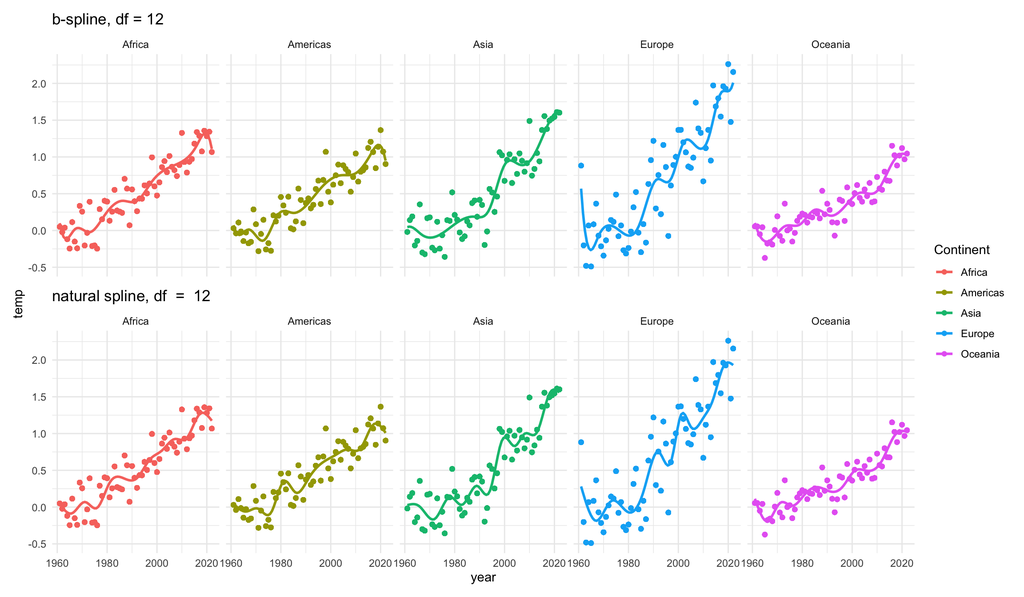

```r
ggplot(climate, aes(year, temp, col = Continent)) +
  geom_smooth(method  = "lm", se = F, formula = y ~ bs(x, df = 12)) +
  geom_point(aes(year, ave_temp)) +
  facet_grid(cols = vars(Continent)) +
  ggtitle("b-spline, df = 12") +
ggplot(climate, aes(year, temp, col = Continent)) +
  geom_smooth(method  = "lm", se = F, formula = y ~ ns(x, df = 12)) +
  geom_point(aes(year, ave_temp)) +
  facet_grid(cols = vars(Continent)) +
  ggtitle("natural spline, df  =  12") +
plot_layout(ncol = 1, guides = "collect", axes = "collect") & theme_minimal()
```

```r
# c leaner version
# p_bs12 <- ggplot(climate, aes(x = year, y = ave_temp, color = Continent)) +
#   geom_point() +
#   geom_smooth(method = "lm", se = FALSE, formula = y ~ bs(x, df = 12)) +
#   facet_grid(cols = vars(Continent)) +
#   ggtitle("B-spline (df = 12)") +
#   labs(x = "Year", y = "Average temperature change") +
#   theme_minimal()
#
# p_ns12 <- ggplot(climate, aes(x = year, y = ave_temp, color = Continent)) +
#   geom_point() +
#   geom_smooth(method = "lm", se = FALSE, formula = y ~ ns(x, df = 12)) +
#   facet_grid(cols = vars(Continent)) +
#   ggtitle("Natural spline (df = 12)") +
#   labs(x = "Year", y = "Average temperature change") +
#   theme_minimal()
#
# (p_bs12 / p_ns12) + plot_layout(ncol = 1, guides = "collect")
```

2. The spline fits with `df = 12` may be too flexible (high variance).  
   Repeat part (a) using a **smaller** number of degrees of freedom and stop when you think the fit achieves a good **bias–variance trade-off**.

   **Hint:** Try values such as `df = 3`, `df = 4`, `df = 5` … and see which curve smoothly tracks the average temperature without capturing the local noisy spikes.

**Show Answer**

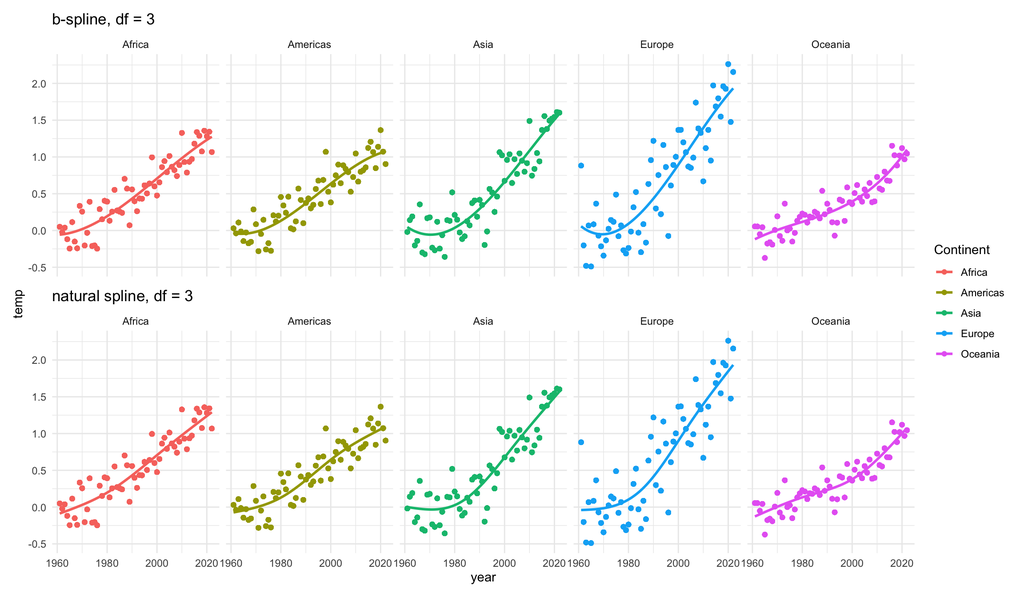

```r
ggplot(climate, aes(year, temp, col = Continent)) +
  geom_smooth(method  = "lm", se = F, formula = y ~ bs(x, df = 3)) +
  geom_point(aes(year, ave_temp)) +
  facet_grid(cols = vars(Continent)) +
  ggtitle("b-spline, df = 3") +
ggplot(climate, aes(year, temp, col = Continent)) +
  geom_smooth(method  = "lm", se = F, formula = y ~ ns(x, df = 3)) +
  geom_point(aes(year, ave_temp)) +
  facet_grid(cols = vars(Continent)) +
  ggtitle("natural spline, df = 3") +
plot_layout(ncol = 1, guides = "collect", axes = "collect") & theme_minimal()
```

```r
# cleaner version:
# df_try <- 3   # change this value to explore different levels of flexibility

# p_bs <- ggplot(climate, aes(x = year, y = ave_temp, color = Continent)) +
#   geom_point() +
#   geom_smooth(method = "lm", se = FALSE, formula = y ~ bs(x, df = df_try)) +
#   facet_grid(cols = vars(Continent)) +
#   ggtitle(paste0("B-spline (df = ", df_try, ")")) +
#   labs(x = "Year", y = "Average temperature change") +
#   theme_minimal()
#
# p_ns <- ggplot(climate, aes(x = year, y = ave_temp, color = Continent)) +
#   geom_point() +
#   geom_smooth(method = "lm", se = FALSE, formula = y ~ ns(x, df = df_try)) +
#   facet_grid(cols = vars(Continent)) +
#   ggtitle(paste0("Natural spline (df = ", df_try, ")")) +
#   labs(x = "Year", y = "Average temperature change") +
#   theme_minimal()
#
# (p_bs / p_ns) + plot_layout(ncol = 1, guides = "collect")
```

## 4.3 Forecasting with splines

Spline regression models can also be used to **extrapolate** trends beyond the observed time period. That is, they can be used to forecast the temperature changes. In this section, we forecast temperature change for the years **2023–2030** and compare how forecasts differ for:

- **B-splines vs natural splines**, and
- **low flexibility (`df = 3`) vs high flexibility (`df = 12`)**

We will fit the models using data from **1961–2022**, and then generate predictions for **2023–2030**.

1. Fit the four spline regression models to the `climate` data (1961–2022) and store the fitted `lm` objects using clear names:
- B-spline with `df = 3`
- Natural spline with `df = 3`
- B-spline with `df = 12`
- Natural spline with `df = 12`

  **Hint:** Use `lm(temp ~ bs(year, df) * Continent, data = climate)` so that each continent can have a different trend over time.

**Show Answer**

```r
b3  <- lm(temp ~ bs(year,  3) * Continent, data = climate)
n3  <- lm(temp ~ ns(year,  3) * Continent, data = climate)
b12 <- lm(temp ~ bs(year, 12) * Continent, data = climate)
n12 <- lm(temp ~ ns(year, 12) * Continent, data = climate)
```

2. Create a new data frame `climate_plus` that contains:
- `year` from **1961 to 2030**, and
- the corresponding values of `Continent`.

  This data frame will be used to generate forecasts for the years **2023–2030**.

  **Hint:** Use `bind_rows()` to append the new data frame of future years to the existing `year` and `Continent` columns.

**Show Answer**

```r
climate_plus <- bind_rows(
  select(climate, year, Continent),
  data.frame(year      = rep(2023:2030, 5),
             Continent = factor(rep(levels(climate$Continent), times = 8)))
)

# you can Use `expand_grid()` (from `tidyr`) to create all combinations of years and continents.
#
#
# climate_plus <- expand_grid(
#   year = 1961:2030,
#   Continent = levels(climate$Continent))
```

3. Create a data frame `ave_plus` containing the **averaged yearly predictions per continent** for each of the four models.

   **Hint:**
   1. Use `predict(model, newdata = climate_plus)` inside `mutate()` to generate predictions.
   2. Then use `summarize(..., .by = c(year, Continent))` to compute the means.

**Show Answer**

```r
ave_plus <- climate_plus %>%
  mutate(
    b3  = predict(b3,  newdata = climate_plus),
    n3  = predict(n3,  newdata = climate_plus),
    b12 = predict(b12, newdata = climate_plus),
    n12 = predict(n12, newdata = climate_plus)
  )  %>%
  summarize(ave_b3 = mean(b3),
            ave_n3 = mean(n3),
            ave_b12 = mean(b12),
            ave_n12 = mean(n12), .by = c(year, Continent))
```

4. Plot the averaged predictions stored in `ave_plus` in **one figure**, and interpret the forecasts for **2023–2030**.

   **Hint:** Build 4 individual plots mapped to `year` and the specific model’s averaged predictions (e.g., `y = ave_b3`), faceting each by `Continent`. Combine them using `(p1 / p2 / p3 / p4)` with patchwork.

**Show Answer**

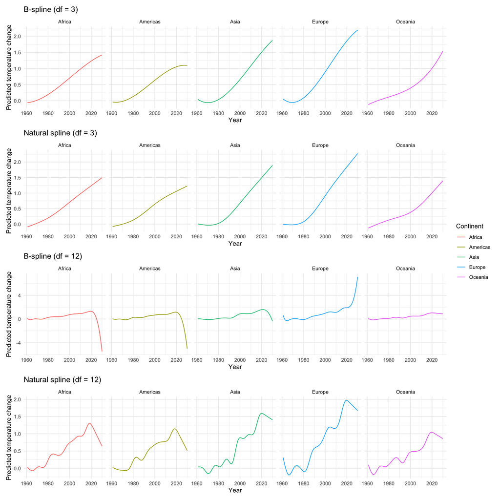

```r
p_b3 <- ggplot(ave_plus, aes(x = year, y = ave_b3, color = Continent)) +
  geom_line() +
  facet_grid(cols = vars(Continent)) +
  ggtitle("B-spline (df = 3)") +
  labs(x = "Year", y = "Predicted temperature change") +
  theme_minimal()

p_n3 <- ggplot(ave_plus, aes(x = year, y = ave_n3, color = Continent)) +
  geom_line() +
  facet_grid(cols = vars(Continent)) +
  ggtitle("Natural spline (df = 3)") +
  labs(x = "Year", y = "Predicted temperature change") +
  theme_minimal()

p_b12 <- ggplot(ave_plus, aes(x = year, y = ave_b12, color = Continent)) +
  geom_line() +
  facet_grid(cols = vars(Continent)) +
  ggtitle("B-spline (df = 12)") +
  labs(x = "Year", y = "Predicted temperature change") +
  theme_minimal()

p_n12 <- ggplot(ave_plus, aes(x = year, y = ave_n12, color = Continent)) +
  geom_line() +
  facet_grid(cols = vars(Continent)) +
  ggtitle("Natural spline (df = 12)") +
  labs(x = "Year", y = "Predicted temperature change") +
  theme_minimal()

(p_b3 / p_n3 / p_b12 / p_n12) + plot_layout(ncol = 1, guides = "collect")
```

# 5 Conclusion

In this lab, we explored **feature space expansions** as a way to model non-linear relationships using linear regression.

We learned that:

- Polynomial regression increases flexibility by adding powers of the predictor, but high-degree polynomials may lead to instability and overfitting, specially near the boundaries.
- B-splines and natural splines provide a more controlled and stable way to model non-linear trends.
- The number of degrees of freedom (`df`) controls model flexibility:
  - Larger `df` leads to lower bias but higher variance
  - Smaller `df` leads to higher bias but lower variance
- Natural splines differ from B-splines mainly in their behavior at the boundaries:  
  natural splines are constrained to be linear beyond the boundary knots, leading to more stable extrapolation.

In the climate forecasting exercise, we observed that:

- Highly flexible models (`df = 12`) can produce unstable forecasts outside the observed data range.
- More parsimonious models (`df = 3`) tend to produce smoother and more realistic extrapolations.
- Model choice strongly affects long-term predictions.

So, this lab illustrated how model flexibility influences fit, interpretation, and forecasting performance. Understanding the **bias–variance trade-off** is crucial when selecting the appropriate level of complexity.

END OF LAB